# STUDENT PERFORMANCE ANALYSIS

#### Handling outliers

```python
for i in std_num_cols:
    Q1 = std_data[i].quantile(0.25)
    Q3 = std_data[i].quantile(0.75)
    IQR = Q3 - Q1
    UW = Q3 + 1.5 * IQR
    LW = Q1 - 1.5 * IQR
    std_data[i] = np.clip(std_data[i], LW, UW)
```

#### Checking whether the outlier filled or not

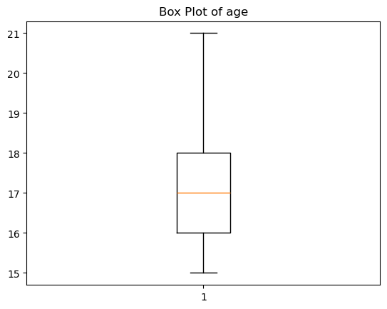

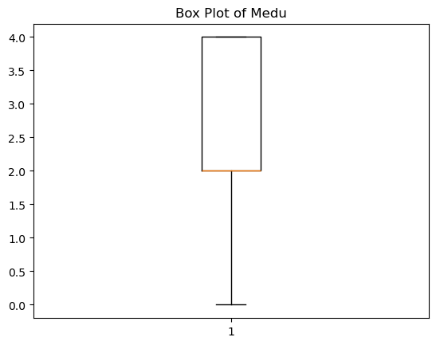

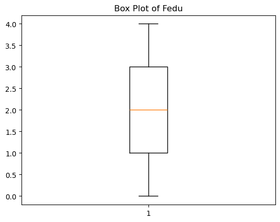

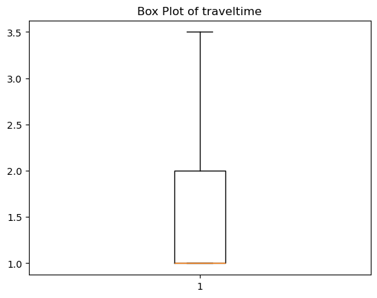

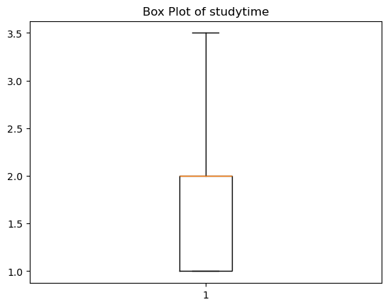

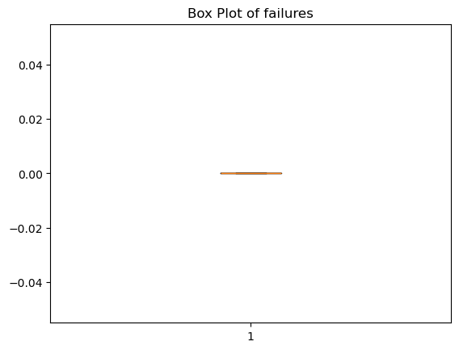

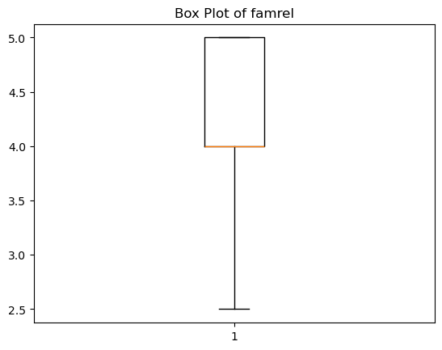

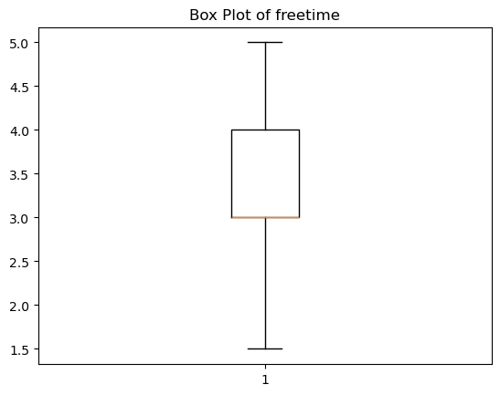

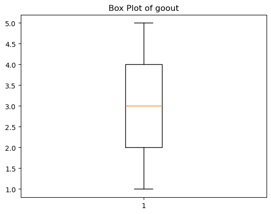

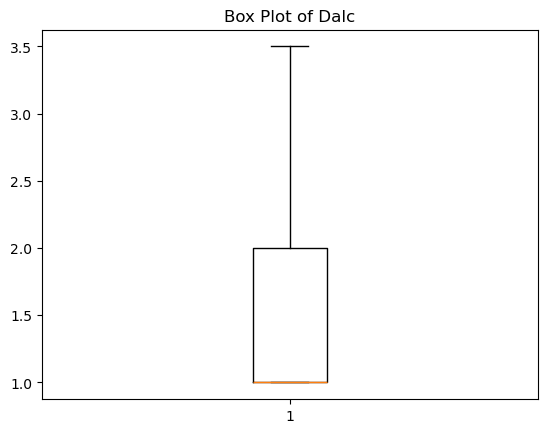

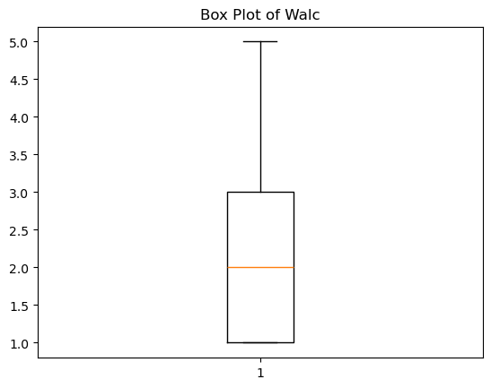

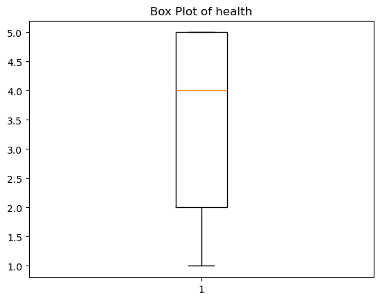

[5 more figures not shown]

```python
for i in std_num_cols:
    plt.boxplot(std_data[i])
    plt.title(f"Box Plot of {i}")
    plt.show()
```

- Outliers successfully handled.

# ENCODING

```python
# Assigning categorical features to a variable
categorical_columns = ['school', 'sex', 'address', 'famsize', 'Pstatus', 'Mjob', 'Fjob',
                       'reason', 'guardian', 'schoolsup', 'famsup', 'paid', 'activities',
                       'nursery', 'higher', 'internet', 'romantic','grade_band']
```

```python
# Initializing Label Encoder
le = LabelEncoder()
```

```python
for column in categorical_columns:
    std_data[column] = le.fit_transform(std_data[column])
```

```python
std_data
```

|  | school | sex | age | address | famsize | Pstatus | Medu | Fedu | Mjob | Fjob | ... | goout | Dalc | Walc | health | absences | G1 | G2 | G3 | grade_band | Mean |
| --- | --- | --- | --- | --- | --- | --- | --- | --- | --- | --- | --- | --- | --- | --- | --- | --- | --- | --- | --- | --- | --- |
| 0 | 0 | 0 | 18 | 1 | 0 | 0 | 4 | 4 | 0 | 4 | ... | 4 | 1.0 | 1 | 3 | 4 | 5.5 | 11.0 | 11 | 2 | 7.333333 |
| 1 | 0 | 0 | 17 | 1 | 0 | 1 | 1 | 1 | 0 | 2 | ... | 3 | 1.0 | 1 | 3 | 2 | 9.0 | 11.0 | 11 | 2 | 10.333333 |
| 2 | 0 | 0 | 15 | 1 | 1 | 1 | 1 | 1 | 0 | 2 | ... | 2 | 2.0 | 3 | 3 | 6 | 12.0 | 13.0 | 12 | 2 | 12.333333 |
| 3 | 0 | 0 | 15 | 1 | 0 | 1 | 4 | 2 | 1 | 3 | ... | 2 | 1.0 | 1 | 5 | 0 | 14.0 | 14.0 | 14 | 2 | 14.000000 |
| 4 | 0 | 0 | 16 | 1 | 0 | 1 | 3 | 3 | 2 | 2 | ... | 2 | 1.0 | 2 | 5 | 0 | 11.0 | 13.0 | 13 | 2 | 12.333333 |
| ... | ... | ... | ... | ... | ... | ... | ... | ... | ... | ... | ... | ... | ... | ... | ... | ... | ... | ... | ... | ... | ... |
| 644 | 1 | 0 | 19 | 0 | 0 | 1 | 2 | 3 | 3 | 2 | ... | 2 | 1.0 | 2 | 5 | 4 | 10.0 | 11.0 | 10 | 2 | 10.333333 |
| 645 | 1 | 0 | 18 | 1 | 1 | 1 | 3 | 1 | 4 | 3 | ... | 4 | 1.0 | 1 | 1 | 4 | 15.0 | 15.0 | 16 | 0 | 15.333333 |
| 646 | 1 | 0 | 18 | 1 | 0 | 1 | 1 | 1 | 2 | 2 | ... | 1 | 1.0 | 1 | 5 | 6 | 11.0 | 12.0 | 9 | 1 | 10.666667 |
| 647 | 1 | 1 | 17 | 1 | 1 | 1 | 3 | 1 | 3 | 3 | ... | 5 | 3.0 | 4 | 2 | 6 | 10.0 | 10.0 | 10 | 2 | 10.000000 |
| 648 | 1 | 1 | 18 | 0 | 1 | 1 | 3 | 2 | 3 | 2 | ... | 1 | 3.0 | 4 | 5 | 4 | 10.0 | 11.0 | 11 | 2 | 10.666667 |

649 rows × 35 columns

```python
data = std_data.copy()
```

```python
data
```

|  | school | sex | age | address | famsize | Pstatus | Medu | Fedu | Mjob | Fjob | ... | goout | Dalc | Walc | health | absences | G1 | G2 | G3 | grade_band | Mean |
| --- | --- | --- | --- | --- | --- | --- | --- | --- | --- | --- | --- | --- | --- | --- | --- | --- | --- | --- | --- | --- | --- |
| 0 | 0 | 0 | 18 | 1 | 0 | 0 | 4 | 4 | 0 | 4 | ... | 4 | 1.0 | 1 | 3 | 4 | 5.5 | 11.0 | 11 | 2 | 7.333333 |
| 1 | 0 | 0 | 17 | 1 | 0 | 1 | 1 | 1 | 0 | 2 | ... | 3 | 1.0 | 1 | 3 | 2 | 9.0 | 11.0 | 11 | 2 | 10.333333 |
| 2 | 0 | 0 | 15 | 1 | 1 | 1 | 1 | 1 | 0 | 2 | ... | 2 | 2.0 | 3 | 3 | 6 | 12.0 | 13.0 | 12 | 2 | 12.333333 |
| 3 | 0 | 0 | 15 | 1 | 0 | 1 | 4 | 2 | 1 | 3 | ... | 2 | 1.0 | 1 | 5 | 0 | 14.0 | 14.0 | 14 | 2 | 14.000000 |
| 4 | 0 | 0 | 16 | 1 | 0 | 1 | 3 | 3 | 2 | 2 | ... | 2 | 1.0 | 2 | 5 | 0 | 11.0 | 13.0 | 13 | 2 | 12.333333 |
| ... | ... | ... | ... | ... | ... | ... | ... | ... | ... | ... | ... | ... | ... | ... | ... | ... | ... | ... | ... | ... | ... |
| 644 | 1 | 0 | 19 | 0 | 0 | 1 | 2 | 3 | 3 | 2 | ... | 2 | 1.0 | 2 | 5 | 4 | 10.0 | 11.0 | 10 | 2 | 10.333333 |
| 645 | 1 | 0 | 18 | 1 | 1 | 1 | 3 | 1 | 4 | 3 | ... | 4 | 1.0 | 1 | 1 | 4 | 15.0 | 15.0 | 16 | 0 | 15.333333 |
| 646 | 1 | 0 | 18 | 1 | 0 | 1 | 1 | 1 | 2 | 2 | ... | 1 | 1.0 | 1 | 5 | 6 | 11.0 | 12.0 | 9 | 1 | 10.666667 |
| 647 | 1 | 1 | 17 | 1 | 1 | 1 | 3 | 1 | 3 | 3 | ... | 5 | 3.0 | 4 | 2 | 6 | 10.0 | 10.0 | 10 | 2 | 10.000000 |
| 648 | 1 | 1 | 18 | 0 | 1 | 1 | 3 | 2 | 3 | 2 | ... | 1 | 3.0 | 4 | 5 | 4 | 10.0 | 11.0 | 11 | 2 | 10.666667 |

649 rows × 35 columns

# SCALING

```python
# Initializing Standard Scaler
scaler = StandardScaler()
```

```python
# Fitting to data
std_data = scaler.fit_transform(std_data)
```

```python
std_data
```

```
array([[-7.30943883e-01, -8.33376848e-01,  1.03810913e+00, ...,
        -3.44194779e-01,  6.11518645e-01, -1.58493514e+00],
       [-7.30943883e-01, -8.33376848e-01,  2.12456157e-01, ...,
        -3.44194779e-01,  6.11518645e-01, -4.85848574e-01],
       [-7.30943883e-01, -8.33376848e-01, -1.43884978e+00, ...,
        -1.05743404e-03,  6.11518645e-01,  2.46875805e-01],
       ...,
       [ 1.36809408e+00, -8.33376848e-01,  1.03810913e+00, ...,
        -1.03046947e+00, -5.83889791e-01, -3.63727844e-01],
       [ 1.36809408e+00,  1.19993734e+00,  2.12456157e-01, ...,
        -6.87332124e-01,  6.11518645e-01, -6.07969304e-01],
       [ 1.36809408e+00,  1.19993734e+00,  1.03810913e+00, ...,
        -3.44194779e-01,  6.11518645e-01, -3.63727844e-01]])
```

#### Creating scaled array into Dataframe

```python
col_names = ['school', 'sex', 'age', 'address', 'famsize', 'Pstatus', 'Medu', 'Fedu',
       'Mjob', 'Fjob', 'reason', 'guardian', 'traveltime', 'studytime',
       'failures', 'schoolsup', 'famsup', 'paid', 'activities', 'nursery',
       'higher', 'internet', 'romantic', 'famrel', 'freetime', 'goout', 'Dalc',
       'Walc', 'health', 'absences', 'G1', 'G2', 'G3', 'grade_band', 'Mean']
```

```python
df = pd.DataFrame(std_data, columns=col_names)
```

```python
df
```

|  | school | sex | age | address | famsize | Pstatus | Medu | Fedu | Mjob | Fjob | ... | goout | Dalc | Walc | health | absences | G1 | G2 | G3 | grade_band | Mean |
| --- | --- | --- | --- | --- | --- | --- | --- | --- | --- | --- | --- | --- | --- | --- | --- | --- | --- | --- | --- | --- | --- |
| 0 | -0.730944 | -0.833377 | 1.038109 | 0.660182 | -0.648175 | -2.666927 | 1.310216 | 1.540715 | -1.556453 | 2.057248 | ... | 0.693785 | -0.592589 | -0.997695 | -0.371042 | 0.120013 | -2.206630 | -0.230013 | -0.344195 | 0.611519 | -1.584935 |
| 1 | -0.730944 | -0.833377 | 0.212456 | 0.660182 | -0.648175 | 0.374963 | -1.336039 | -1.188832 | -1.556453 | -0.260728 | ... | -0.157380 | -0.592589 | -0.997695 | -0.371042 | -0.369851 | -0.899455 | -0.230013 | -0.344195 | 0.611519 | -0.485849 |
| 2 | -0.730944 | -0.833377 | -1.438850 | 0.660182 | 1.542792 | 0.374963 | -1.336039 | -1.188832 | -1.556453 | -0.260728 | ... | -1.008546 | 0.724501 | 0.560678 | -0.371042 | 0.609876 | 0.220979 | 0.513590 | -0.001057 | 0.611519 | 0.246876 |
| 3 | -0.730944 | -0.833377 | -1.438850 | 0.660182 | -0.648175 | 0.374963 | 1.310216 | -0.278983 | -0.754756 | 0.898260 | ... | -1.008546 | -0.592589 | -0.997695 | 1.012903 | -0.859714 | 0.967936 | 0.885391 | 0.685217 | 0.611519 | 0.857479 |
| 4 | -0.730944 | -0.833377 | -0.613197 | 0.660182 | -0.648175 | 0.374963 | 0.428131 | 0.630866 | 0.046941 | -0.260728 | ... | -1.008546 | -0.592589 | -0.218508 | 1.012903 | -0.859714 | -0.152499 | 0.513590 | 0.342080 | 0.611519 | 0.246876 |
| ... | ... | ... | ... | ... | ... | ... | ... | ... | ... | ... | ... | ... | ... | ... | ... | ... | ... | ... | ... | ... | ... |
| 644 | 1.368094 | -0.833377 | 1.863762 | -1.514733 | -0.648175 | 0.374963 | -0.453954 | 0.630866 | 0.848637 | -0.260728 | ... | -1.008546 | -0.592589 | -0.218508 | 1.012903 | 0.120013 | -0.525977 | -0.230013 | -0.687332 | 0.611519 | -0.485849 |
| 645 | 1.368094 | -0.833377 | 1.038109 | 0.660182 | 1.542792 | 0.374963 | 0.428131 | -1.188832 | 1.650334 | 0.898260 | ... | 0.693785 | -0.592589 | -0.997695 | -1.754987 | 0.120013 | 1.341414 | 1.257192 | 1.371492 | -1.779298 | 1.345962 |
| 646 | 1.368094 | -0.833377 | 1.038109 | 0.660182 | -0.648175 | 0.374963 | -1.336039 | -1.188832 | 0.046941 | -0.260728 | ... | -1.859711 | -0.592589 | -0.997695 | 1.012903 | 0.609876 | -0.152499 | 0.141789 | -1.030469 | -0.583890 | -0.363728 |
| 647 | 1.368094 | 1.199937 | 0.212456 | 0.660182 | 1.542792 | 0.374963 | 0.428131 | -1.188832 | 0.848637 | 0.898260 | ... | 1.544950 | 2.041591 | 1.339864 | -1.063015 | 0.609876 | -0.525977 | -0.601814 | -0.687332 | 0.611519 | -0.607969 |
| 648 | 1.368094 | 1.199937 | 1.038109 | -1.514733 | 1.542792 | 0.374963 | 0.428131 | -0.278983 | 0.848637 | -0.260728 | ... | -1.859711 | 2.041591 | 1.339864 | 1.012903 | 0.120013 | -0.525977 | -0.230013 | -0.344195 | 0.611519 | -0.363728 |

649 rows × 35 columns

# MODEL BUILDING

```python
# Splitting variables into data and target
X = df.drop(columns=['G3'])
y = df['G3']
```

#### Train-Test-Split

```python
# Assuming X_train, X_test, y_train, y_test are already defined
X_train, X_test, y_train, y_test = train_test_split(X, y, test_size=0.2, random_state=42)
```

#### Model Building

```python
# Define models
models = {
    'Linear Regression': LinearRegression(),
    'Ridge Regression': Ridge(),
    'Lasso Regression': Lasso(),
    'ElasticNet Regression': ElasticNet(),
    'Decision Tree': DecisionTreeRegressor(),
    'Random Forest': RandomForestRegressor(),
    'Gradient Boosting': GradientBoostingRegressor(),
    'XGBoost': XGBRegressor(verbosity=0),
    'LightGBM': LGBMRegressor(),
    'CatBoost': CatBoostRegressor(verbose=0)
}
```

```python
# Store metrics
results = []
```

```python
for name, model in models.items():
    model.fit(X_train, y_train)
    preds = model.predict(X_test)

    mae = mean_absolute_error(y_test, preds)
    mse = mean_squared_error(y_test, preds)
    rmse = np.sqrt(mse)
    r2 = r2_score(y_test, preds)

    results.append({
        'Model': name,
        'MAE': round(mae, 2),
        'MSE': round(mse, 2),
        'RMSE': round(rmse, 2),
        'R²': round(r2, 2)
    })
```

[output not shown]

[output cut: 51 more lines]

[output not shown]

```python
# Convert results to DataFrame for better display
results_df = pd.DataFrame(results)
```

```python
results_df
```

|  | Model | MAE | MSE | RMSE | R² |
| --- | --- | --- | --- | --- | --- |
| 0 | Linear Regression | 0.07 | 0.01 | 0.10 | 0.99 |
| 1 | Ridge Regression | 0.08 | 0.01 | 0.11 | 0.99 |
| 2 | Lasso Regression | 0.80 | 1.03 | 1.01 | -0.03 |
| 3 | ElasticNet Regression | 0.50 | 0.41 | 0.64 | 0.58 |
| 4 | Decision Tree | 0.13 | 0.05 | 0.23 | 0.95 |
| 5 | Random Forest | 0.13 | 0.03 | 0.17 | 0.97 |
| 6 | Gradient Boosting | 0.11 | 0.02 | 0.15 | 0.98 |
| 7 | XGBoost | 0.09 | 0.02 | 0.13 | 0.98 |
| 8 | LightGBM | 0.13 | 0.03 | 0.17 | 0.97 |
| 9 | CatBoost | 0.13 | 0.03 | 0.17 | 0.97 |

# VISUALIZING MODEL PERFORMANCE

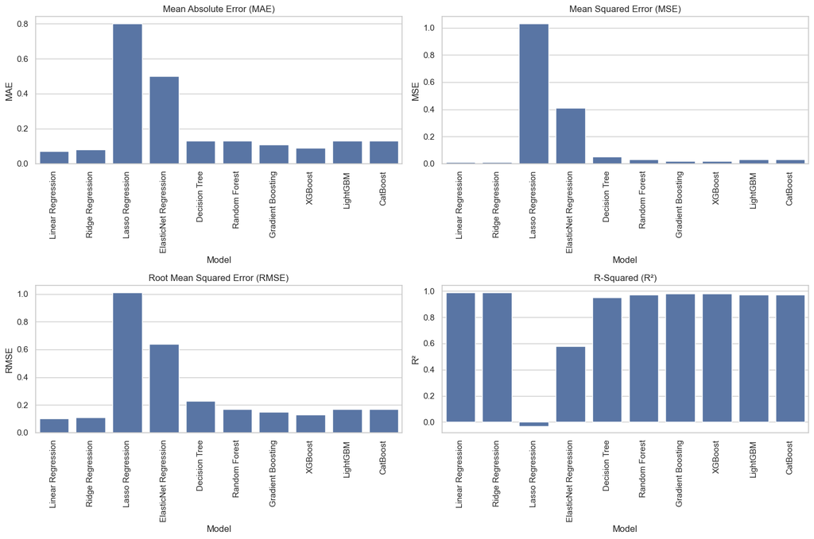

```python
# Set the style
sns.set(style="whitegrid")

# Plot the metrics
fig, axs = plt.subplots(2, 2, figsize=(15, 10))

sns.barplot(x="Model", y="MAE", data=results_df, ax=axs[0, 0])
axs[0, 0].set_title("Mean Absolute Error (MAE)")
axs[0, 0].tick_params(axis='x', rotation=90)

sns.barplot(x="Model", y="MSE", data=results_df, ax=axs[0, 1])
axs[0, 1].set_title("Mean Squared Error (MSE)")
axs[0, 1].tick_params(axis='x', rotation=90)

sns.barplot(x="Model", y="RMSE", data=results_df, ax=axs[1, 0])
axs[1, 0].set_title("Root Mean Squared Error (RMSE)")
axs[1, 0].tick_params(axis='x', rotation=90)

sns.barplot(x="Model", y="R²", data=results_df, ax=axs[1, 1])
axs[1, 1].set_title("R-Squared (R²)")
axs[1, 1].tick_params(axis='x', rotation=90)

plt.tight_layout()
```

# EVALUATE THE MODEL

```python
# Initialize and train Linear Regression model
model = LinearRegression()
model.fit(X_train, y_train)
```

```
LinearRegression()
```

```python
# Make predictions
preds = model.predict(X_test)
```

```python
# Evaluate model
mae = mean_absolute_error(y_test, preds)
mse = mean_squared_error(y_test, preds)
rmse = np.sqrt(mse)
r2 = r2_score(y_test, preds)
```

```python
# Print results
print("Linear Regression Results:")
print(f"MAE:  {mae:.2f}")
print(f"MSE:  {mse:.2f}")
print(f"RMSE: {rmse:.2f}")
print(f"R²:   {r2:.2f}")
```

```
Linear Regression Results:
MAE:  0.07
MSE:  0.01
RMSE: 0.10
R²:   0.99
```

# PLOTTING FEATURE IMPORTANCE

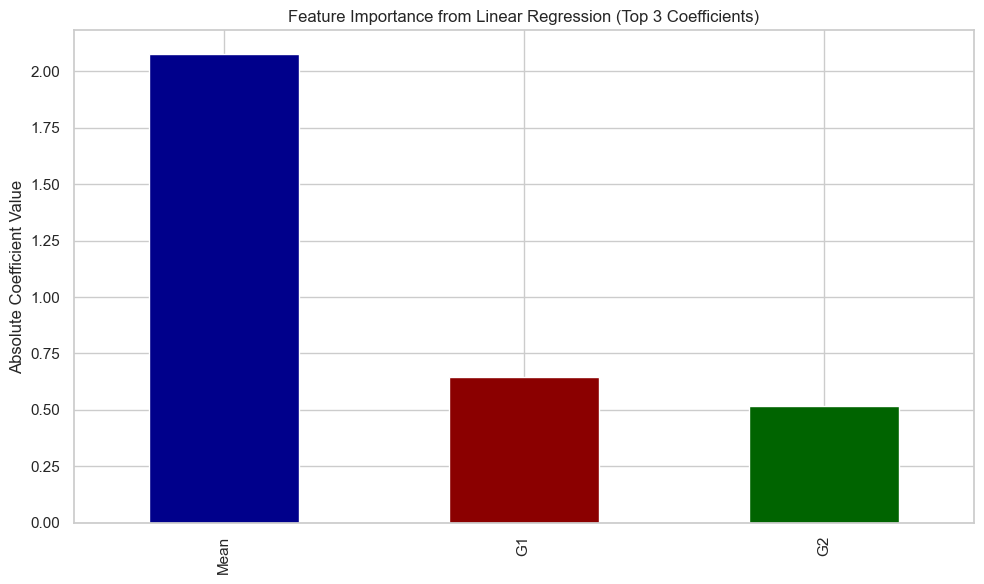

```python
# Fit the Linear Regression model
lr = LinearRegression()
lr.fit(X, y)

# Assigning feature importance (coefficients) into a variable
importances = pd.Series(lr.coef_, index=X.columns)

# Setting it into descending order by absolute value
importances = importances.abs().sort_values(ascending=False).head(3)  # Top 10 features

# Plot the feature importance
plt.figure(figsize=(10,6))
importances.plot(kind='bar', color=['darkblue','darkred','darkgreen'])
plt.title('Feature Importance from Linear Regression (Top 3 Coefficients)')
plt.ylabel('Absolute Coefficient Value')
plt.tight_layout()
plt.show()
```

# CONCLUSION

- The objective of this project was to predict students’ final academic performance (G3) using a variety of features from the Portuguese Student Performance Dataset.
- Through a systematic data science workflow, we applied exploratory data analysis (EDA), data preprocessing, and multiple regression models to identify the best predictive model.
- The first (G1) and second (G2) period grades showed a very high positive correlation with the final grade (G3), making them strong predictors.
- Other factors such as study time, failures, and absences were also meaningfully associated with academic outcomes.
- Students with fewer past failures, higher parental education, and more study time tended to perform better.
- High alcohol consumption (especially during weekdays) and more frequent social outings were negatively correlated with G3.
- Having access to educational support, a stable family relationship, and planning for higher education also positively impacted performance.
- Final grades (G3) had a right-skewed distribution, with a majority of students scoring between 10 and 15. There were fewer high and failing scores.
- Linear Regression emerged as the best-performing model due to its simplicity, interpretability, and good generalization on the dataset.
- It achieved a high R² score, indicating a strong fit between predicted and actual grades.
- The study successfully demonstrated that academic history (G1 and G2), study habits, and support systems significantly impact a student's final academic performance.